# Interpretability for Tree Ensembles

Biostat 274

Author

Dr. Jin Zhou @ UCLA

Published

February 4, 2026

Credit: This note builds on tree/ensemble material from [*An Introduction to Statistical Learning: with Applications in R*](https://www.statlearning.com/) (ISL2) and [*Elements of Statistical Learning*](https://hastie.su.domains/ElemStatLearn/) (ESL2), and introduces modern interpretability + feature selection tools including **permutation importance**, **Shapley/SHAP**, and **Boruta**.

Display system information for reproducibility.

**R**

**Python**

```python
import IPython
print(IPython.sys_info())
```

```
{'commit_hash': '5ed988a91',
 'commit_source': 'installation',
 'default_encoding': 'utf-8',
 'ipython_path': '/Users/jinjinzhou/.virtualenvs/r-tensorflow/lib/python3.10/site-packages/IPython',
 'ipython_version': '8.33.0',
 'os_name': 'posix',
 'platform': 'macOS-15.7.3-arm64-arm-64bit',
 'sys_executable': '/Users/jinjinzhou/.virtualenvs/r-tensorflow/bin/python',
 'sys_platform': 'darwin',
 'sys_version': '3.10.16 (main, Mar  3 2025, 20:01:33) [Clang 16.0.0 '
                '(clang-1600.0.26.6)]'}
```

# 1 Why interpretability after trees?

- A **single** decision tree is often interpretable: you can read off splitting rules and explain predictions with a small number of paths.
- But the most accurate tree-based predictors in practice are often **ensembles**:
  - **Bagging / Random Forests**: average many (deep) trees.
  - **Boosted trees**: add many small trees sequentially.
- Ensembles improve accuracy *but* can become **black-box-ish**. We therefore need post-hoc tools for:
  1. **Interpretability / explanation** (What drives predictions?)
  2. **Variable importance** (Which predictors matter most?)
  3. **Variable selection** (Which predictors are *reliably* useful?)

**NoteGlobal vs. local interpretability**

- **Global**: summarize the model as a whole  
  (e.g., *which* variables are important overall?)
- **Local**: explain *one* prediction  
  (e.g., *why* did this patient get a high risk score?)

Variable importance is usually **global**. SHAP can do **local + global**.  
Boruta is a **selection** procedure (all-relevant feature selection).

# 2 Variable importance

## 2.1 What does “importance” mean?

Importance is *not* a single concept. Two common notions:

1. **Model-usage importance**: how often / how strongly the model uses a variable  
   (e.g., total loss reduction from splits on that variable).
2. **Predictive importance**: how much predictive performance drops when a variable is destroyed  
   (e.g., permute a variable and re-score the model).

These can disagree, especially with correlated predictors.

**NoteImportance is not causality**

A variable can be “important” to a predictive model because it is correlated with the outcome, correlated with a true cause, or even due to data leakage. Variable-importance tools answer:

> “Does the trained model rely on this variable to predict well?”

They do **not** answer:

> “Does this variable cause the outcome?”

## 2.2 Split / impurity importance (tree-specific)

For a tree, each internal node $t$ splits the data into left/right children. Let $I(t)$ be an **impurity** measure at node $t$:

- Regression: $I(t)$ can be $RSS(t)$ or $MSE(t)$.
- Classification: $I(t)$ can be **Gini** or **entropy**.

If node $t$ splits into children $t_L,t_R$, define the impurity decrease (a “gain”)

$$\Delta I(t)
=
I(t)
-
\frac{n_{L}}{n_t} I(t_L)
-
\frac{n_{R}}{n_t} I(t_R),$$

where $n_t$ is the number of training samples reaching node $t$.

If feature $j$ is used at node $t$, its (tree) importance is typically

$$VI_j
=
\sum_{t: v(t)=j} \Delta I(t).$$

For **random forests / bagging**, average $VI_j$ across trees.

### 2.2.1 Pros / cons

Pros:

- Computed “for free” during training.
- Available in most tree software.

Cons / pitfalls:

- Can be biased toward variables with **many possible split points** (continuous features, high-cardinality categories).
- With **correlated predictors**, importance is often “shared” and can be unstable.

## 2.3 Permutation importance (model-agnostic)

Permutation importance measures predictive importance:

1. Evaluate a trained model on a validation set (or OOB samples) to get a baseline score.
2. For feature $j$, randomly permute its values (break its association with $y$ but keep marginal distribution).
3. Re-score the model; importance is the score drop.

If $M(\cdot)$ is a metric where larger is better (e.g., accuracy, $R^2$), then

$$PI_j = M(\text{original}) - M(\text{permuted } j).$$

**NotePermutation importance (typical algorithm)**

Given trained model $\hat f$ and evaluation set $\mathcal D$:

1. Compute baseline metric: $m_0 \leftarrow M(\hat f, \mathcal D)$.
2. For each feature $j=1,\dots,p$:
   1. Create a permuted copy $\mathcal D^{\pi(j)}$ by shuffling column $j$.
   2. Compute $m_j \leftarrow M(\hat f, \mathcal D^{\pi(j)})$.
   3. Set importance $PI_j \leftarrow m_0 - m_j$.
3. (Optional) Repeat permutations several times and average.

Using **OOB samples** in random forests gives a built-in evaluation set without extra CV.

### 2.3.1 Pros / cons

Pros: - Works for **any** model and any performance metric. - Typically less biased than split/impurity importance.

Cons / pitfalls: - With **correlated / redundant** predictors, permutation importance can be misleading: - If $X_j$ is redundant with $X_k$, permuting $X_j$ might not hurt because $X_k$ “substitutes”. - Or permuting $X_j$ can break dependence structure and create unrealistic inputs. - Importance depends on the **chosen metric** and **evaluation distribution**.

## 2.4 Importance in boosted trees (XGBoost / LightGBM style)

Many boosting libraries report importance summaries such as:

- **Gain**: total loss reduction attributed to splits on a feature.
- **Frequency**: number of times a feature is used in splits.
- **Cover**: number of observations affected by splits (library-dependent definition).

These are fast and convenient, but:

- they are still “model-usage” measures (not performance-drop),
- they may behave oddly with correlated predictors or different hyperparameters.

A good workflow is:

- report **both** (gain/split importance *and* permutation importance),
- then use **SHAP** for detailed interpretation.

# 3 Worked example data: `Hitters` (salary regression)

We reuse the baseball salary data (`Hitters`) from the tree lecture.  
Goal: predict `Salary` from player statistics.

**R**

```r
library(tidymodels)
library(ISLR2)

# Remove missing Salary rows for supervised learning
Hitters2 <- Hitters %>% drop_na(Salary)

# A simple train/test split (used throughout)
set.seed(1)
hitters_split <- initial_split(Hitters2, prop = 0.7)
hitters_train <- training(hitters_split)
hitters_test  <- testing(hitters_split)

Hitters2 %>%
  summarise(
    n = n(),
    p = ncol(.),
    salary_min = min(Salary),
    salary_median = median(Salary),
    salary_max = max(Salary)
  )
```

```
    n  p salary_min salary_median salary_max
1 263 20       67.5           425       2460
```

**Python**

Load `Hitters` data (adapt path to your course repo if needed):

```python
import pandas as pd
import numpy as np

# If you already used this path in the tree lecture, keep it consistent.
# Hitters = pd.read_csv("./slides/data/Hitters.csv")
# For standalone demos, change to wherever your Hitters.csv lives.
Hitters = pd.read_csv("./slides/data/Hitters.csv")

# Drop missing Salary
Hitters2 = Hitters.dropna(subset=["Salary"]).copy()
Hitters2.shape
```

```
(263, 20)
```

# 4 Variable importance in random forests

## 4.1 Random forest: split vs permutation importance

- Split/impurity importance answers: “Which variables reduce impurity most often?”
- Permutation importance answers: “Which variables, when destroyed, hurt prediction most?”

In practice, compare the two.

**R (tidymodels + ranger)**

```r
# install.packages(c("tidymodels","vip","ranger"))
library(tidymodels)
library(vip)

set.seed(1)

# Model specs: same algorithm, different importance definitions
rf_perm_spec <-
  rand_forest(trees = 1000) %>%
  set_engine("ranger", importance = "permutation") %>%
  set_mode("regression")

rf_impurity_spec <-
  rand_forest(trees = 1000) %>%
  set_engine("ranger", importance = "impurity") %>%
  set_mode("regression")

rf_perm_wf <-
  workflow() %>%
  add_model(rf_perm_spec) %>%
  add_formula(Salary ~ .)

rf_impurity_wf <- rf_perm_wf %>%
  update_model(rf_impurity_spec)

rf_perm_fit <- fit(rf_perm_wf, data = hitters_train)
rf_impurity_fit <- fit(rf_impurity_wf, data = hitters_train)

# Test set performance (tidymodels + yardstick)
rf_test <-
  hitters_test %>%
  select(Salary) %>%
  bind_cols(predict(rf_perm_fit, hitters_test))

metric_set(rmse, rsq)(rf_test, truth = Salary, estimate = .pred)
```

```
# A tibble: 2 × 3
  .metric .estimator .estimate
  <chr>   <chr>          <dbl>
1 rmse    standard     310.
2 rsq     standard       0.570
```

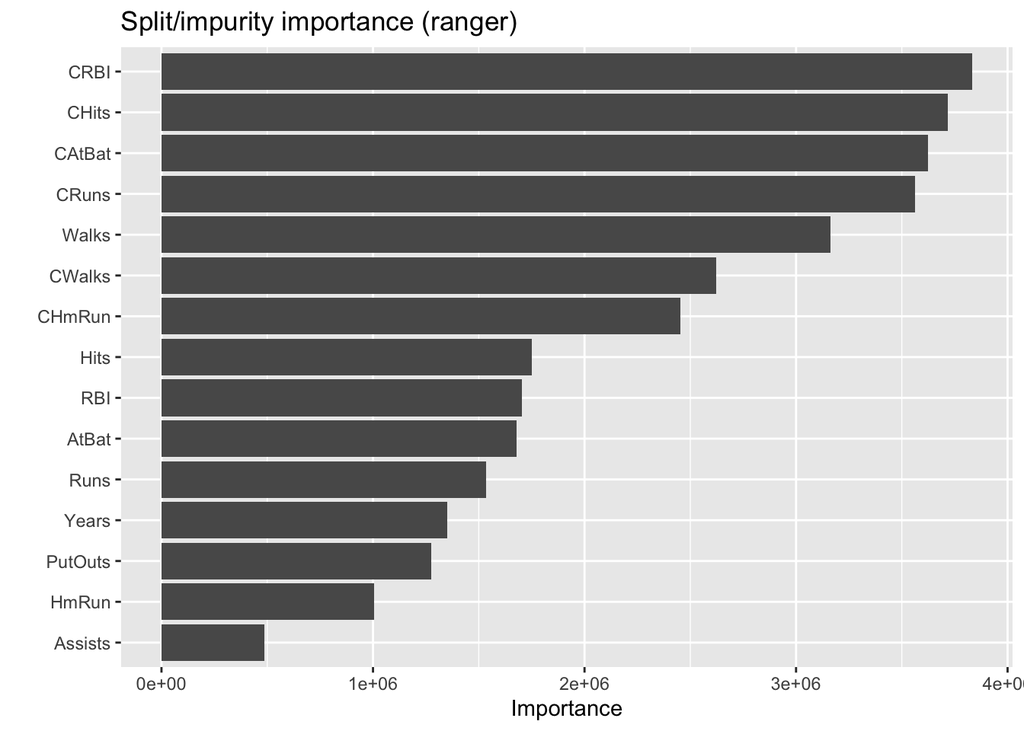

```r
# --- Variable importance plots ---
# Split/impurity importance
vip(extract_fit_engine(rf_impurity_fit), num_features = 15) +
  ggtitle("Split/impurity importance (ranger)")
```

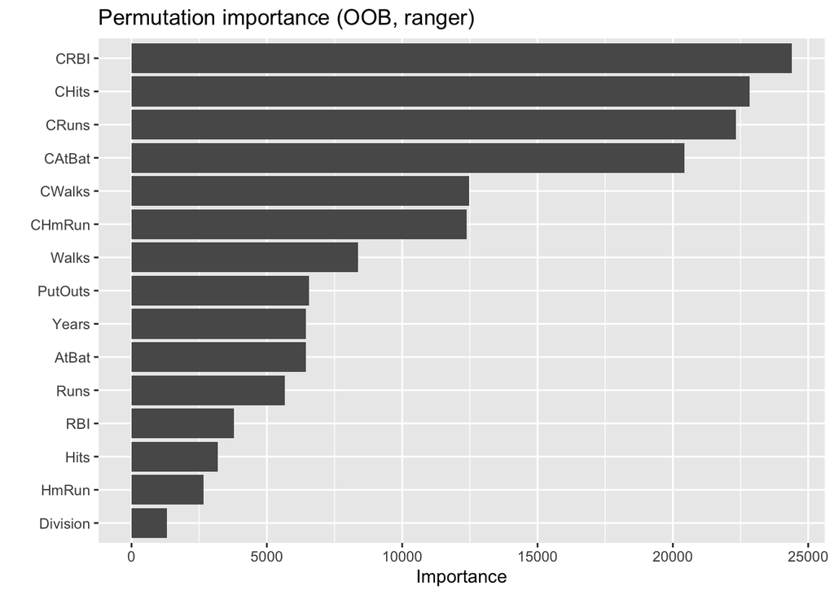

```r
# Permutation importance (OOB, computed by ranger)
vip(extract_fit_engine(rf_perm_fit), num_features = 15) +
  ggtitle("Permutation importance (OOB, ranger)")
```

**Python (sklearn permutation_importance)**

```python
from sklearn.model_selection import train_test_split
from sklearn.compose import ColumnTransformer
from sklearn.pipeline import Pipeline
from sklearn.preprocessing import OneHotEncoder
from sklearn.metrics import r2_score
from sklearn.ensemble import RandomForestRegressor
from sklearn.inspection import permutation_importance

# Features / outcome
y = Hitters2["Salary"].values
X = Hitters2.drop(columns=["Salary"])

# Identify categorical columns (object / category)
cat_cols = X.select_dtypes(include=["object", "category"]).columns.tolist()
num_cols = [c for c in X.columns if c not in cat_cols]

preprocess = ColumnTransformer(
    transformers=[
        ("num", "passthrough", num_cols),
        ("cat", OneHotEncoder(handle_unknown="ignore"), cat_cols),
    ]
)

rf = RandomForestRegressor(
    n_estimators=1000,
    random_state=1,
    n_jobs=-1
)

X_train, X_test, y_train, y_test = train_test_split(
    X, y, test_size=0.3, random_state=1
)

pipe = Pipeline(steps=[("prep", preprocess), ("model", rf)])
pipe.fit(X_train, y_train)
```

```
Pipeline(steps=[('prep',
                 ColumnTransformer(transformers=[('num', 'passthrough',
                                                  ['AtBat', 'Hits', 'HmRun',
                                                   'Runs', 'RBI', 'Walks',
                                                   'Years', 'CAtBat', 'CHits',
                                                   'CHmRun', 'CRuns', 'CRBI',
                                                   'CWalks', 'PutOuts',
                                                   'Assists', 'Errors']),
                                                 ('cat',
                                                  OneHotEncoder(handle_unknown='ignore'),
                                                  ['League', 'Division',
                                                   'NewLeague'])])),
                ('model',
                 RandomForestRegressor(n_estimators=1000, n_jobs=-1,
                                       random_state=1))])
```

```python
yhat = pipe.predict(X_test)
print("Test R^2:", r2_score(y_test, yhat))
```

```
Test R^2: 0.5885785746919341
```

```python
# Permutation importance on the test set (model-agnostic)
perm = permutation_importance(
    pipe, X_test, y_test,
    n_repeats=10,
    random_state=1,
    n_jobs=-1
)

# Show top features (note: one-hot expands categories)
importances = perm.importances_mean
feat_names = pipe.named_steps["prep"].get_feature_names_out()
top_idx = np.argsort(importances)[::-1][:15]

list(zip(feat_names[top_idx], importances[top_idx]))
```

[output not shown]

**TipStability check (recommended)**

Variable importance can be noisy. For a more reliable ranking:

- compute permutation importance with multiple random seeds,
- or bootstrap the training data, refit the model many times, and summarize importance variability.

If importance is unstable across resamples, be cautious about “top-1/top-2” claims.

# 5 Shapley values and SHAP

## 5.1 Shapley values (game theory)

- Suppose a “game” has $p$ players.
- The game produces a payoff $v(S)$ for any coalition (subset) $S$ of players.
- The **Shapley value** assigns each player $j$ a fair contribution $\phi_j$.

For a feature-attribution view:

- players = features,
- payoff = model prediction (relative to a baseline).

The Shapley value for feature $j$ is

$$\phi_j
=
\sum_{S\subseteq F\setminus\{j\}}
\frac{|S|!(p-|S|-1)!}{p!}
\left[ v(S\cup\{j\}) - v(S) \right].$$

Key properties:

- **Efficiency**: contributions sum to total payoff.
- **Symmetry**: identical players get equal credit.
- **Dummy**: irrelevant player gets zero.
- **Additivity**: for combined games, contributions add.

## 5.2 SHAP in ML: local explanations that add up

SHAP (SHapley Additive exPlanations) is a family of methods that uses Shapley values to explain individual predictions.

For an observation $x$:

$$\hat f(x) = \phi_0 + \sum_{j=1}^p \phi_j,$$

where:

- $\phi_0$ is a baseline (often $\mathbb E[\hat f(X)]$),
- $\phi_j$ is the contribution of feature $j$ for this specific $x$.

### 5.2.1 Global importance from SHAP

A common global ranking is:

$$\text{SHAP-Importance}_j = \mathbb E\left[ |\phi_j| \right],$$

estimated by the sample mean of $|\phi_j|$ over observations.

**NoteTreeSHAP**

For tree-based models, SHAP values can be computed efficiently using **TreeSHAP**, which exploits the tree structure rather than enumerating all $2^p$ coalitions.

Takeaway:

- SHAP is practical for random forests and boosted trees.

## 5.3 Interpreting SHAP plots (common patterns)

- **Bar plot (mean |SHAP|)**: global importance ranking.
- **Beeswarm / summary plot**: each dot is one observation; color shows feature value.
- **Dependence plot**: SHAP value vs. feature value; reveals nonlinearity + interactions.
- **Waterfall / force plot**: a single observation explanation.

**NoteClassification caveat: units of SHAP values**

For classification, SHAP values can be in:

- **log-odds** (common for many tree models),
- or **probability space** (sometimes available depending on implementation).

Always check the explainer settings and interpret units accordingly.

# 6 SHAP example (boosted trees)

We illustrate SHAP for a boosted-tree regressor on `Hitters`.

**R (tidymodels + xgboost + shapviz)**

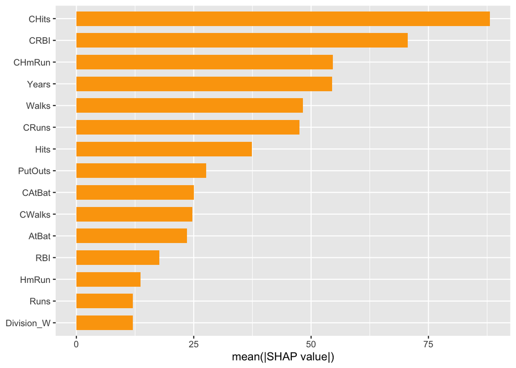

```r
# install.packages(c("tidymodels","xgboost","shapviz"))
library(tidymodels)
library(shapviz)

set.seed(1)

# Recipe: xgboost needs numeric predictors -> one-hot encode factors
hitters_xgb_rec <-
  recipe(Salary ~ ., data = hitters_train) %>%
  step_dummy(all_nominal_predictors()) %>%
  step_zv(all_predictors())

# Prep once so we can (1) choose mtry ~ 80% of columns and (2) reuse baked data for SHAP
hitters_xgb_prep <- prep(hitters_xgb_rec)

p <- juice(hitters_xgb_prep) %>% select(-Salary) %>% ncol()
mtry_val <- max(1, floor(0.8 * p))

xgb_spec <-
  boost_tree(
    trees = 500,
    tree_depth = 3,
    learn_rate = 0.05,
    sample_size = 0.8,
    mtry = mtry_val
  ) %>%
  set_engine("xgboost") %>%
  set_mode("regression")

xgb_wf <-
  workflow() %>%
  add_recipe(hitters_xgb_rec) %>%
  add_model(xgb_spec)

xgb_fit <- fit(xgb_wf, data = hitters_train)

# SHAP needs the xgboost engine + the baked predictor matrix
xgb_engine <- extract_fit_engine(xgb_fit)

X_train <-
  bake(hitters_xgb_prep, new_data = hitters_train) %>%
  select(-Salary) %>%
  as.matrix()

sv <- shapviz(xgb_engine, X_pred = X_train)

# Global importance (mean |SHAP|)
sv_importance(sv, kind = "bar")
```

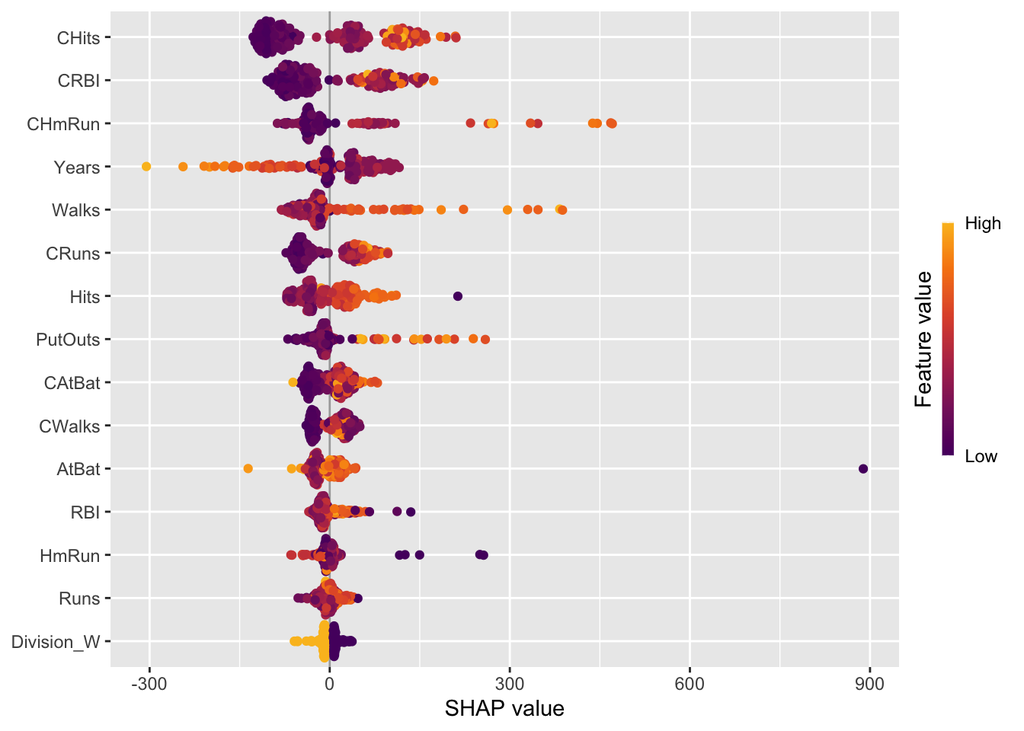

```r
# Beeswarm summary plot
sv_importance(sv, kind = "beeswarm")
```

**Python (sklearn GradientBoosting + shap)**

```python
# If you see ModuleNotFoundError for shap, install it into THIS Python:
#   python -m pip install shap
# (Optional auto-install)
try:
    import shap
except ImportError:
    import sys, subprocess
    subprocess.check_call([sys.executable, "-m", "pip", "install", "shap"])
    import shap

import pandas as pd
import numpy as np

from sklearn.model_selection import train_test_split
from sklearn.compose import ColumnTransformer
from sklearn.preprocessing import OneHotEncoder
from sklearn.pipeline import Pipeline
from sklearn.impute import SimpleImputer
from sklearn.ensemble import GradientBoostingRegressor

# --- Data (make this chunk self-contained) ---
# If Hitters2 was created earlier, reuse it; otherwise load it here.
if "Hitters2" not in globals():
    Hitters = pd.read_csv("./slides/data/Hitters.csv")
    Hitters2 = Hitters.dropna(subset=["Salary"]).copy()

y = Hitters2["Salary"].values
X = Hitters2.drop(columns=["Salary"])

# Identify categorical vs numeric columns
cat_cols = X.select_dtypes(include=["object", "category"]).columns.tolist()
num_cols = [c for c in X.columns if c not in cat_cols]

# OneHotEncoder dense output across scikit-learn versions
try:
    ohe = OneHotEncoder(handle_unknown="ignore", sparse_output=False)
except TypeError:
    ohe = OneHotEncoder(handle_unknown="ignore", sparse=False)

preprocess = ColumnTransformer(
    transformers=[
        ("num", Pipeline([("impute", SimpleImputer(strategy="median"))]), num_cols),
        ("cat", Pipeline([
            ("impute", SimpleImputer(strategy="most_frequent")),
            ("onehot", ohe)
        ]), cat_cols),
    ],
    remainder="drop",
    verbose_feature_names_out=False
)

gbr = GradientBoostingRegressor(random_state=1)

# Pipeline: preprocess -> model
pipe_gbr = Pipeline(steps=[("preprocess", preprocess), ("model", gbr)])

X_train, X_test, y_train, y_test = train_test_split(
    X, y, test_size=0.3, random_state=1
)

pipe_gbr.fit(X_train, y_train)
```

```
Pipeline(steps=[('preprocess',
                 ColumnTransformer(transformers=[('num',
                                                  Pipeline(steps=[('impute',
                                                                   SimpleImputer(strategy='median'))]),
                                                  ['AtBat', 'Hits', 'HmRun',
                                                   'Runs', 'RBI', 'Walks',
                                                   'Years', 'CAtBat', 'CHits',
                                                   'CHmRun', 'CRuns', 'CRBI',
                                                   'CWalks', 'PutOuts',
                                                   'Assists', 'Errors']),
                                                 ('cat',
                                                  Pipeline(steps=[('impute',
                                                                   SimpleImputer(strategy='most_frequent')),
                                                                  ('onehot',
                                                                   OneHotEncoder(handle_unknown='ignore',
                                                                                 sparse_output=False))]),
                                                  ['League', 'Division',
                                                   'NewLeague'])],
                                   verbose_feature_names_out=False)),
                ('model', GradientBoostingRegressor(random_state=1))])
```

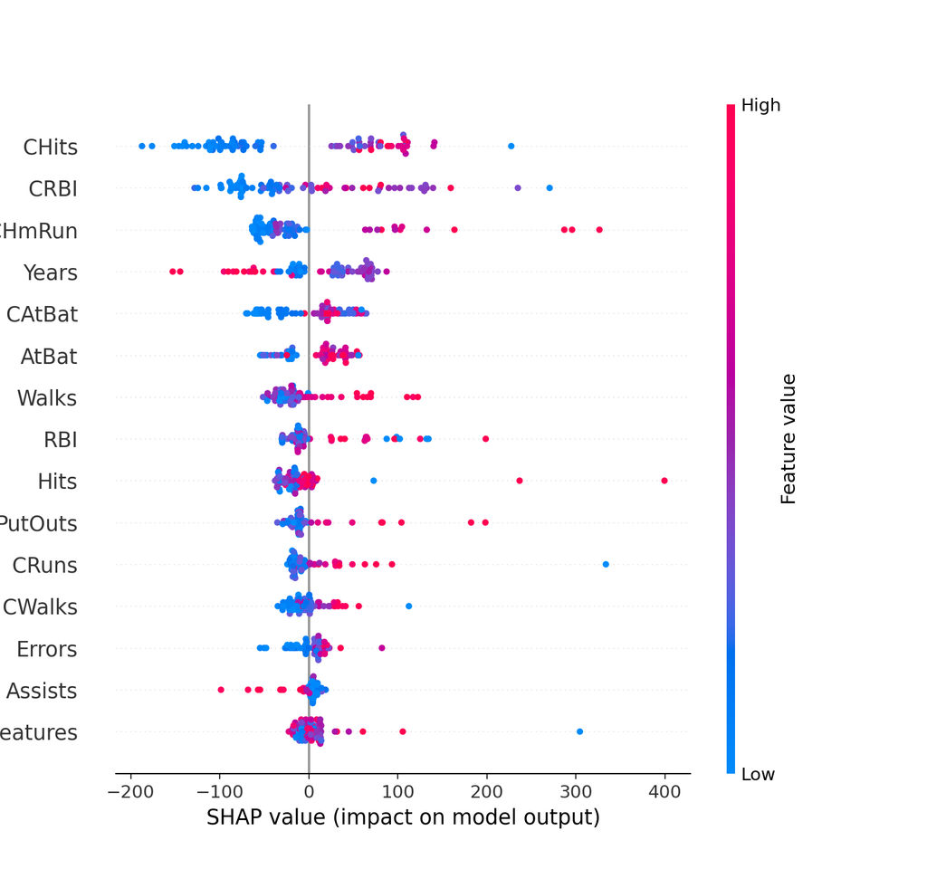

```python
# --- SHAP in the transformed feature space ---
X_train_trans = pipe_gbr.named_steps["preprocess"].transform(X_train)
X_test_trans  = pipe_gbr.named_steps["preprocess"].transform(X_test)

feat_names = pipe_gbr.named_steps["preprocess"].get_feature_names_out()

X_train_shap = pd.DataFrame(X_train_trans, columns=feat_names)
X_test_shap  = pd.DataFrame(X_test_trans,  columns=feat_names)

model = pipe_gbr.named_steps["model"]

# TreeSHAP (fast for tree ensembles)
explainer = shap.Explainer(model, X_train_shap)
shap_values = explainer(X_test_shap)

# Beeswarm summary plot
shap.plots.beeswarm(shap_values, max_display=15)
```

```python
# (Optional) global bar plot
# shap.plots.bar(shap_values, max_display=15)
```

# 7 Boruta: all-relevant variable selection

## 7.1 Variable selection vs. variable importance

- **Importance**: rank variables by some score (often continuous).
- **Selection**: decide a set of variables to keep (a discrete decision).

Boruta is designed for **all-relevant** selection:

> Keep *every* variable that has evidence of being useful, even if redundant with others.

This is different from minimal-optimal selection (keep the smallest set with good accuracy).

## 7.2 Boruta idea: compare to “shadow” features

Boruta wraps around a random forest:

1. Create “shadow” variables by permuting each original feature column to destroy association with $y$.
2. Fit a random forest and compute importance for original + shadow features.
3. A real feature is “confirmed” only if it consistently beats the **best** shadow feature.

**NoteBoruta algorithm (high level)**

Repeat for $r=1,\dots,R$:

1. Create shadow features: for each $j$, make $X_j^{shadow}$ by permuting $X_j$.
2. Fit RF on $[X, X^{shadow}]$ and compute importance scores.
3. Let $M_r = \max_j \text{Imp}(X_j^{shadow})$ (the strongest shadow).
4. For each real feature $j$:
   - if $\text{Imp}(X_j) > M_r$ consistently → **Confirmed**
   - if $\text{Imp}(X_j) < M_r$ consistently → **Rejected**
   - otherwise → **Tentative**

Stop when all features are decided or max iterations reached.

### 7.2.1 Practical notes

- Boruta is computationally heavier than just computing importance once.
- It is **random forest-based**, so results depend on RF settings (trees, mtry, etc.).
- With strong collinearity, Boruta may confirm multiple redundant predictors (this is expected under “all-relevant” philosophy).

# 8 Boruta example: selecting predictors for `Salary`

**R (Boruta + tidymodels split)**

```r
# install.packages(c("tidymodels","Boruta"))
library(tidymodels)
library(Boruta)

set.seed(1)

# Run Boruta on the training set only (avoid peeking at the test set)
# Use default ranger RF settings; increase maxRuns for more stability
bor_fit <- Boruta(
  Salary ~ .,
  data = hitters_train,
  doTrace = 1,
  maxRuns = 200
)

# Resolve tentative attributes (common practical step)
bor_fix <- TentativeRoughFix(bor_fit)

# Tidy summary of decisions
bor_tbl <-
  attStats(bor_fix) %>%
  as_tibble(rownames = "feature") %>%
  arrange(desc(meanImp))

bor_tbl
```

```
# A tibble: 19 × 7
   feature   meanImp medianImp minImp maxImp normHits decision
   <chr>       <dbl>     <dbl>  <dbl>  <dbl>    <dbl> <fct>
 1 CHits      10.8      10.7    8.80   12.8   1       Confirmed
 2 CRuns      10.6      10.6    8.40   12.6   1       Confirmed
 3 CAtBat     10.4      10.4    8.31   12.3   1       Confirmed
 4 CRBI        9.21      9.20   7.46   10.9   1       Confirmed
 5 CWalks      8.21      8.21   6.07   10.4   1       Confirmed
 6 CHmRun      7.58      7.58   5.12    9.50  1       Confirmed
 7 Walks       7.07      7.07   5.07    9.32  1       Confirmed
 8 AtBat       6.73      6.71   4.26    8.71  0.990   Confirmed
 9 Years       6.61      6.66   4.46    8.53  0.995   Confirmed
10 PutOuts     5.77      5.73   3.60    7.93  0.985   Confirmed
11 Hits        5.57      5.55   3.30    8.19  0.985   Confirmed
12 Runs        5.31      5.38   2.37    7.29  0.975   Confirmed
13 RBI         4.36      4.46   2.29    7.02  0.920   Confirmed
14 HmRun       3.21      3.13   0.441   5.91  0.709   Confirmed
15 Division    2.19      2.20  -0.458   4.46  0.432   Rejected
16 League      0.777     0.651 -0.771   3.75  0.00503 Rejected
17 NewLeague   0.150    -0.298 -1.33    1.93  0       Rejected
18 Errors     -0.210    -0.105 -2.36    2.23  0       Rejected
19 Assists    -0.778    -0.988 -2.11    1.08  0       Rejected
```

```r
# Selected variables
bor_tbl %>%
  filter(decision == "Confirmed") %>%
  pull(feature)
```

```
 [1] "CHits"   "CRuns"   "CAtBat"  "CRBI"    "CWalks"  "CHmRun"  "Walks"
 [8] "AtBat"   "Years"   "PutOuts" "Hits"    "Runs"    "RBI"     "HmRun"
```

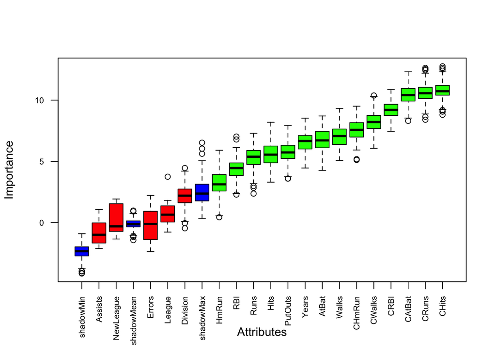

```r
# Visualization
plot(bor_fix, las = 2, cex.axis = 0.7)
```

**Python (BorutaPy)**

```python
# If you see ModuleNotFoundError for boruta, install it into THIS Python:
#   python -m pip install boruta
# (Optional auto-install)
try:
    from boruta import BorutaPy
except ImportError:
    import sys, subprocess
    subprocess.check_call([sys.executable, "-m", "pip", "install", "boruta"])
    from boruta import BorutaPy

import pandas as pd
import numpy as np

from sklearn.compose import ColumnTransformer
from sklearn.preprocessing import OneHotEncoder
from sklearn.pipeline import Pipeline
from sklearn.impute import SimpleImputer
from sklearn.ensemble import RandomForestRegressor

# --- Data (make this chunk self-contained) ---
if "Hitters2" not in globals():
    Hitters = pd.read_csv("./slides/data/Hitters.csv")
    Hitters2 = Hitters.dropna(subset=["Salary"]).copy()

X_all = Hitters2.drop(columns=["Salary"])
y_all = Hitters2["Salary"].values

cat_cols = X_all.select_dtypes(include=["object", "category"]).columns.tolist()
num_cols = [c for c in X_all.columns if c not in cat_cols]

# OneHotEncoder dense output across scikit-learn versions
try:
    ohe = OneHotEncoder(handle_unknown="ignore", sparse_output=False)
except TypeError:
    ohe = OneHotEncoder(handle_unknown="ignore", sparse=False)

preprocess_b = ColumnTransformer(
    transformers=[
        ("num", Pipeline([("impute", SimpleImputer(strategy="median"))]), num_cols),
        ("cat", Pipeline([
            ("impute", SimpleImputer(strategy="most_frequent")),
            ("onehot", ohe)
        ]), cat_cols),
    ],
    remainder="drop",
    verbose_feature_names_out=False
)

X_all_trans = preprocess_b.fit_transform(X_all)
feat_names = preprocess_b.get_feature_names_out()

rf_for_boruta = RandomForestRegressor(
    n_estimators=2000,
    random_state=1,
    n_jobs=-1
)

boruta = BorutaPy(
    estimator=rf_for_boruta,
    n_estimators="auto",
    random_state=1,
    verbose=2
)

boruta.fit(X_all_trans, y_all)
```

```
BorutaPy(estimator=RandomForestRegressor(n_estimators=46, n_jobs=-1,
                                         random_state=RandomState(MT19937) at 0x169B0EB40),
         n_estimators='auto', random_state=RandomState(MT19937) at 0x169B0EB40,
         verbose=2)
```

```python
selected = feat_names[boruta.support_]
tentative = feat_names[boruta.support_weak_]

print("Confirmed:", len(selected))
```

```
Confirmed: 11
```

```python
print("Tentative:", len(tentative))
```

```
Tentative: 0
```

```python
print("Top confirmed:", selected[:20])
```

```
Top confirmed: ['AtBat' 'Hits' 'Runs' 'RBI' 'Walks' 'CAtBat' 'CHits' 'CHmRun' 'CRuns'
 'CRBI' 'PutOuts']
```

```python
print("Top tentative:", tentative[:20])
```

```
Top tentative: []
```

**TipWhen to use Boruta (and when not)**

Use Boruta when you want:

- a **robust, conservative** set of relevant predictors,
- to guard against spurious “importance” due to RF randomness.

Avoid (or be cautious) when:

- $p$ is extremely large (computational cost),
- features are extremely correlated and you want a *minimal* subset,
- data leakage is possible (Boruta will happily “select” leaked variables).

# 9 Summary: choosing a tool

- **Split / gain importance**
  - Fast, model-specific, good first look.
  - May be biased; not a performance-drop measure.
- **Permutation importance**
  - Model-agnostic, tied to a chosen metric.
  - Sensitive to correlation / dependence structure.
- **SHAP**
  - Local explanations that add up; also yields global rankings.
  - Great for tree ensembles; be careful with correlated features and classification units.
- **Boruta**
  - Wrapper feature selection for “all-relevant” variables.
  - Conservative; may select redundant predictors (by design).

A practical post-ensemble workflow:

1. Fit your best-performing tree ensemble (RF or boosting).
2. Report **permutation importance** (with uncertainty / stability).
3. Use **SHAP** to explain top variables (global + a few representative observations).
4. If you need a selected feature set, run **Boruta** (then refit and re-evaluate).